# Biodiversity Monitoring GGC Meta. Tracking birds in silvopastoral systems

## Preliminary results of the biodiversity component in the projects Sustainable Cattle Ranching [GCS](http://ganaderiacolombianasostenible.co/web/) and Green Growth Compact Meta.

- Background
- Practices
- Areas

## This is part of biodiversity monitoring component of the projects Sustainable Cattle Ranching and Green Growth Compact Meta.

We in the program of the Northern Andes and Southern Central America (NASCA) from The Nature Conservancy (TNC), have been monitoring bats, dung beetle and birds in farms that have being implementing sustainable practices.

- Birds as landscape detectives
- VHF Telemetry
- Adaptative kernel home range

## Sustainable practices include live fences and silvopastoral systems to connect isolated forest patches and to increase cattle ranching productivity.

- Live Fences
- Yopo in silvopastoral
- Connectivity corridors

## We work in Meta and Quindio.

We have selected a monitoring place in la Rosania farm were the owners and the Sustainable Cattle Ranching project have created a large patch of yopo tree (Anadenanthera peregrina) as part of his silvopastoral practices.

- Mist Netteing
- Bird track
- Conectivity landscapes

## Our Methods

Since January 2017 we have been monitoring the movement of birds using VHF radio telemetry.

### VHF Telemetry

We use two Wildlife materials VHF receivers and an old Lotek VHF telemetry receiver simultaneously.

### Analysis

We have adapted and written code in the statistical software [R](https://www.R-project.org) to perform the analysis.

### Possibilities

The data gathered allows to understand the movement ecology of poor known species and to evaluate how birds use corridors implemented by the project.

### Code and Data

Our code and data will be freely available in [github](https://github.com/dlizcano/VHF_Telemetry) and [Movebank](https://www.movebank.org/).

### Maps

Mapping movement and silvopastoral use intensity.

### Support Conservation

Our data and results support biodiviversity conservation in productive landscapes.

## Field work

### Telemetry tracking

## Piedmont

### Cubarral

## Bird handling

### Telemetry emisor installing

## Meet The Team

We are a group of ornitologist, entomologist and wildlife biologists working hard to collect the best data.

[figure not shown]

### Thomas Walsburger

#### Senior Scientific Advisor, TNC

Thomas designed and orient the reseach.

[figure not shown]

### Diego J. Lizcano

#### Biodiviersity Specialist, TNC

Diego use his skills in wildlife biology and statistics to analize the data.

[figure not shown]

### Alejandro Lopera

#### Science Director, GAICA

[figure not shown]

### Robert Rodriguez

#### Ornitologist, GAICA

[figure not shown]

### Yuri Rodriguez

#### Ornitologist, GAICA

[figure not shown]

### David Chapeta

#### MSc. Student, Javeriana University

# Biodiversity Monitoring GGC Meta

Diego J. Lizcano

27th September, 2017

# Tracking birds in silvopastoral systems

## *Tyranus melancholicus*

[figure not shown]

[interactive chart not shown]

## *Capito auratus*

[figure not shown]

[interactive chart not shown]

## *Tangara cayana*

[figure not shown]

[interactive chart not shown]

## *Glyphorynchus spirurus*

[figure not shown]

[interactive chart not shown]

## *Manacus manacus*

[figure not shown]

[interactive chart not shown]

## *Ceratopipra erythrocephala*

[figure not shown]

[interactive chart not shown]

## *Dendrocincla fuliginosa*

[figure not shown]

[interactive chart not shown]

## *Myiarchus tuberculifer*

[figure not shown]

[interactive chart not shown]

## *Thraupis episcopus*

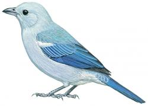

[interactive chart not shown]

## *Momotus momota*

[figure not shown]

[interactive chart not shown]

## *Tolmomyias sulphurescens*

[figure not shown]

[interactive chart not shown]